# H3K4me1 vs H3K27ac

Chenghao Zhu

1/6/2020

```r
library(dplyr)
library(reshape2)
library(ggplot2)
library(rtracklayer)
library(ChIPseeker)
library(clusterProfiler)
library(TxDb.Hsapiens.UCSC.hg38.knownGene)
library(org.Hs.eg.db)
library(biomaRt)
library(ggplot2)
theme_set(theme_classic())
```

Read narrowPeaks

```r
h3k4me1_tx = import(
    gzfile("data/H3K4me1_SR8278.merged.nodup_x_ctl_for_rep1.pval0.01.500K.narrowPeak.gz"),
    format = "narrowPeak"
)
h3k4me1_tx = h3k4me1_tx[h3k4me1_tx$qValue > 2]
h3k27ac_tx = import(
    gzfile("data/H3K27ac_SR8278.merged.nodup_x_ctl_for_rep1.pval0.01.500K.narrowPeak.gz"),
    format = "narrowPeak"
)
h3k27ac_tx = h3k27ac_tx[h3k27ac_tx$qValue > 2]
h3k4me1_ve = import(
    gzfile("data/H3K4me1_Vehicle.merged.nodup_x_ctl_for_rep2.pval0.01.500K.narrowPeak.gz"),
    format = "narrowPeak"
)
h3k4me1_ve = h3k4me1_ve[h3k4me1_ve$qValue > 2]
h3k27ac_ve = import(
    gzfile("data/H3K27ac_Vehicle.merged.nodup_x_ctl_for_rep2.pval0.01.500K.narrowPeak.gz"),
    format = "narrowPeak"
)
h3k27ac_ve = h3k27ac_ve[h3k27ac_ve$qValue > 2]
```

## Find overlap peaks

```r
overlaps_tx = findOverlapPairs(h3k27ac_tx, h3k4me1_tx)
```

[output not shown]

```r
overlaps_tx
```

```
Pairs object with 12963 pairs and 0 metadata columns:
                              first                    second
                          <GRanges>                 <GRanges>
      [1]   chr22:46060807-46062607   chr22:46062342-46062477
      [2]       chr19:679170-681045       chr19:679128-679582
      [3]   chr19:12994995-12998997   chr19:12998824-12999031
      [4]     chr17:7884467-7887290     chr17:7886601-7886743
      [5]      chr4:2535286-2537862      chr4:2535195-2535357
      ...                       ...                       ...
  [12959]   chr17:82241616-82241806   chr17:82241643-82241900
  [12960] chr11:109064850-109065033 chr11:109064802-109064932
  [12961]  chr3:191473575-191473724  chr3:191473694-191473870
  [12962]  chr3:191473575-191473724  chr3:191473398-191473601
  [12963]    chr6:11435605-11435803    chr6:11435748-11435901
```

There are 12,963 overlapped peaks between h3k27ac and h3k4me1 after treatment.

```r
overlaps_ve = findOverlapPairs(h3k27ac_ve, h3k27ac_ve)
overlaps_ve
```

```
Pairs object with 82684 pairs and 0 metadata columns:
                             first                   second
                         <GRanges>                <GRanges>
      [1]  chr15:92882543-92883892  chr15:92882543-92883892
      [2]  chr17:50865174-50867465  chr17:50865174-50867465
      [3]   chr9:97982312-97985630   chr9:97982312-97985630
      [4]  chr12:12561221-12563336  chr12:12561221-12563336
      [5]      chr19:796193-799386      chr19:796193-799386
      ...                      ...                      ...
  [82680] chr9:125696241-125696438 chr9:125696241-125696438
  [82681]   chr9:18206884-18207094   chr9:18206884-18207094
  [82682]   chr9:70165984-70166146   chr9:70165984-70166146
  [82683]   chr9:86501756-86501905   chr9:86501756-86501905
  [82684]   chr9:99339981-99340139   chr9:99339981-99340139
```

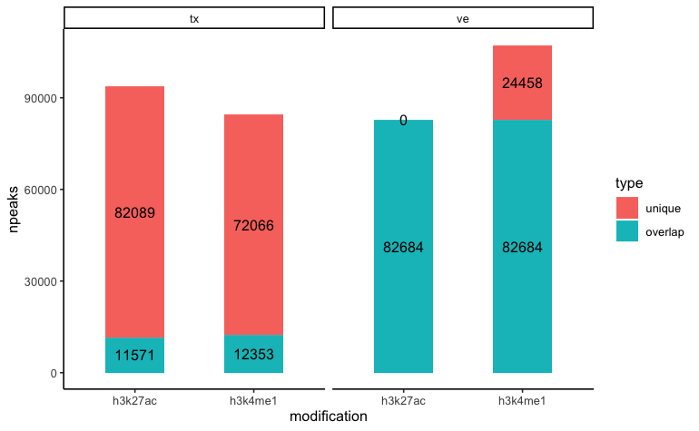

```r
h3k27ac_tx_overlap = length(unique(overlaps_tx@first$name))
h3k4me1_tx_overlap = length(unique(overlaps_tx@second$name))
h3k27ac_ve_overlap = length(unique(overlaps_ve@first$name))
h3k4me1_ve_overlap = length(unique(overlaps_ve@second$name))
data.frame(
    modification = c("h3k27ac", "h3k27ac", "h3k4me1", "h3k4me1",
                "h3k27ac", "h3k27ac", "h3k4me1", "h3k4me1"),
    type = c("unique", "overlap", "unique", "overlap",
             "unique", "overlap", "unique", "overlap"),
    treatment = rep(c("tx", "ve"), each = 4),
    npeaks = c(length(h3k27ac_tx) - h3k27ac_tx_overlap, h3k27ac_tx_overlap,
               length(h3k4me1_tx) - h3k4me1_tx_overlap, h3k4me1_tx_overlap,
               length(h3k27ac_ve) - h3k27ac_ve_overlap, h3k27ac_ve_overlap,
               length(h3k4me1_ve) - h3k4me1_ve_overlap, h3k4me1_ve_overlap),
    anno.y = c((length(h3k27ac_tx) - h3k27ac_tx_overlap)/2 + h3k27ac_tx_overlap,
               h3k27ac_tx_overlap/2,
               (length(h3k4me1_tx) - h3k4me1_tx_overlap)/2 + h3k4me1_tx_overlap,
               h3k4me1_tx_overlap/2,
               (length(h3k27ac_ve) - h3k27ac_ve_overlap)/2 + h3k27ac_ve_overlap,
               h3k27ac_ve_overlap/2,
               (length(h3k4me1_ve) - h3k4me1_ve_overlap)/2 + h3k4me1_ve_overlap,
               h3k4me1_ve_overlap/2)
) %>%
    mutate(type = relevel(type, ref = "unique"),
           anno.y = anno.y + 100) %>%
    ggplot(aes(x = modification, y = npeaks, fill = type)) +
    geom_col(width = 0.5) +
    geom_text(aes(y = anno.y, label = npeaks)) +
    facet_grid(cols = vars(treatment))
```

The total number of peaks in h3k27ac overlap with h3k4me1 does not match with that of h3k4me1 with h3k27ac, because some peaks overlaps with more than one peak from the other modification.

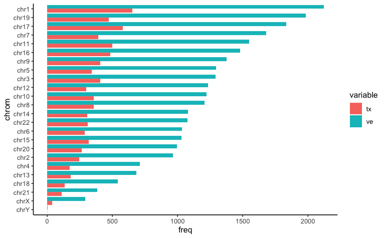

```r
df = merge(
    as.data.frame(table(overlaps_tx@first@seqnames@values)),
    as.data.frame(table(overlaps_ve@first@seqnames@values)),
    by = "Var1"
)
colnames(df) = c("chrom", "tx", "ve")
df %>% filter(chrom %in% paste0("chr", c(1:22, "X", "Y"))) %>%
    arrange(ve) %>%
    mutate(chrom = factor(chrom, levels = chrom)) %>%
    melt(id.vars = "chrom", value.name = "freq") %>%
    ggplot() + geom_col(aes(x = chrom, y = freq, fill = variable), position = "dodge") +
    coord_flip()
```

## Gene annotation

Obtain gene annotations

```r
chroms_ensembl = seqlevels(h3k27ac_tx)
chroms = gsub("^chr", "", chroms_ensembl)
chroms = gsub("^.+?_", "", chroms)
chroms = gsub("_.+$", "", chroms)
chroms = gsub("v([0-9])$", "\\.\\1", chroms)

ensembl = useMart("ensembl", dataset = "hsapiens_gene_ensembl")
anno = getBM(
    mart = ensembl,
    filter = "chromosome_name",
    values = chroms,
    attributes = c("chromosome_name", "start_position", "end_position",
                   "ensembl_gene_id", "external_gene_name", "gene_biotype")
)

anno_granges = GRanges(
    seqnames = chroms_ensembl[match(anno$chromosome_name, chroms)],
    ranges = IRanges(
        start = anno$start_position,
        end = anno$end_position,
        names = anno$ensembl_gene_id
    ),
    gene_name = anno$external_gene_name,
    gene_type = anno$gene_biotype
)
```

```r
tx_ranges = lapply(seq_along(overlaps_tx), function(i){
    start1 = start(overlaps_tx@first[i])
    end1 = end(overlaps_tx@first[i])
    start2 = start(overlaps_tx@second[i])
    end2 = end(overlaps_tx@second[i])
    res = c(min(start1, start2),
            max(end1, end2))
    names(res) = c("start", "end")
    return(res)
}) %>%
    do.call(rbind, .)
tx_granges = GRanges(seqnames = overlaps_tx@first@seqnames,
                     ranges = IRanges(start = tx_ranges[,1], end = tx_ranges[,2]))
anno_tx_overlaps = findOverlaps(tx_granges, anno_granges)
anno_tx = anno_granges
anno_tx$n_overlap = as.integer(table(anno_tx_overlaps@to)[as.character(1:length(anno_tx))])
anno_tx = anno_tx[which(!is.na(anno_tx$n_overlap))]
anno_tx = anno_tx[order(anno_tx$n_overlap, decreasing = TRUE)]
anno_tx
```

```
GRanges object with 6288 ranges and 3 metadata columns:
                  seqnames              ranges strand |   gene_name      gene_type n_overlap
                     <Rle>           <IRanges>  <Rle> | <character>    <character> <integer>
  ENSG00000131149    chr16   85169525-85676204      * |        GSE1 protein_coding        58
  ENSG00000109906    chr11 114059711-114256765      * |      ZBTB16 protein_coding        44
  ENSG00000186350     chr9 134317098-134440585      * |        RXRA protein_coding        36
  ENSG00000205476    chr14   99500190-99604207      * |     CCDC85C protein_coding        34
  ENSG00000130940     chr1   10636604-10796650      * |       CASZ1 protein_coding        33
              ...      ...                 ...    ... .         ...            ...       ...
  ENSG00000013619     chrX 150361422-150514178      * |      MAMLD1 protein_coding         1
  ENSG00000130021     chrX     6667865-7148190      * |        PUDP protein_coding         1
  ENSG00000046651     chrX   13734745-13769357      * |        OFD1 protein_coding         1
  ENSG00000169891     chrX   16946658-17153272      * |       REPS2 protein_coding         1
  ENSG00000131831     chrX   17800049-17861337      * |        RAI2 protein_coding         1
  -------
  seqinfo: 42 sequences from an unspecified genome; no seqlengths
```

```r
ve_ranges = lapply(seq_along(overlaps_ve), function(i){
    start1 = start(overlaps_ve@first[i])
    end1 = end(overlaps_ve@first[i])
    start2 = start(overlaps_ve@second[i])
    end2 = end(overlaps_ve@second[i])
    res = c(min(start1, start2),
            max(end1, end2))
    names(res) = c("start", "end")
    return(res)
}) %>%
    do.call(rbind, .)
ve_granges = GRanges(seqnames = overlaps_ve@first@seqnames,
                     ranges = IRanges(start = ve_ranges[,1], end = ve_ranges[,2]))
anno_ve_overlaps = findOverlaps(ve_granges, anno_granges)
```

[output not shown]

```r
anno_ve = anno_granges
anno_ve$n_overlap = as.integer(table(anno_ve_overlaps@to)[as.character(1:length(anno_ve))])
anno_ve = anno_ve[which(!is.na(anno_ve$n_overlap))]
anno_ve = anno_ve[order(anno_ve$n_overlap, decreasing = TRUE)]
anno_ve
```

```
GRanges object with 24410 ranges and 3 metadata columns:
                  seqnames              ranges strand |   gene_name              gene_type n_overlap
                     <Rle>           <IRanges>  <Rle> | <character>            <character> <integer>
  ENSG00000131149    chr16   85169525-85676204      * |        GSE1         protein_coding       151
  ENSG00000286192     chr7     1815804-2242215      * |  AC069288.1         protein_coding        94
  ENSG00000155093     chr7 157539056-158587823      * |      PTPRN2         protein_coding        93
  ENSG00000002822     chr7     1815793-2233243      * |      MAD1L1         protein_coding        92
  ENSG00000153179    chr12   64507001-64697564      * |      RASSF3         protein_coding        88
              ...      ...                 ...    ... .         ...                    ...       ...
  ENSG00000029993     chrX 150980509-150990771      * |       HMGB3         protein_coding         1
  ENSG00000123575     chrX 104166453-104195902      * |     FAM199X         protein_coding         1
  ENSG00000282840     chrX   11668401-11757718      * |  AC004554.2                 lncRNA         1
  ENSG00000259029     chrY   11321557-11322823      * |     DUX4L18 unprocessed_pseudogene         1
  ENSG00000258991     chrY   11332329-11333595      * |     DUX4L19 unprocessed_pseudogene         1
  -------
  seqinfo: 42 sequences from an unspecified genome; no seqlengths
```

```r
gene_df = left_join(
    data.frame(gene_id   = names(anno_ve),
               gene_name = anno_ve$gene_name,
               n_overlap = anno_ve$n_overlap,
               stringsAsFactors = FALSE),
    data.frame(gene_id   = names(anno_tx),
               gene_name = anno_tx$gene_name,
               n_overlap = anno_tx$n_overlap,
               stringsAsFactors = FALSE),
    by = c("gene_id", "gene_name"),
)
gene_df$n_overlap.y[is.na(gene_df$n_overlap.y)] = 0
colnames(gene_df) = c("gene_id", "gene_name", "ve", "tx")
gene_df = mutate(gene_df, diff = ve - tx) %>%
    arrange(desc(diff))
gene_df
```

| gene_id | gene_name | ve | tx | diff |
| --- | --- | --- | --- | --- |
| ENSG00000131149 | GSE1 | 151 | 58 | 93 |
| ENSG00000286192 | AC069288.1 | 94 | 3 | 91 |
| ENSG00000002822 | MAD1L1 | 92 | 3 | 89 |
| ENSG00000153179 | RASSF3 | 88 | 5 | 83 |
| ENSG00000155093 | PTPRN2 | 93 | 11 | 82 |
| ENSG00000215386 | MIR99AHG | 84 | 3 | 81 |
| ENSG00000064042 | LIMCH1 | 77 | 9 | 68 |
| ENSG00000127663 | KDM4B | 80 | 16 | 64 |
| ENSG00000147050 | KDM6A | 65 | 4 | 61 |
| ENSG00000068383 | INPP5A | 74 | 14 | 60 |

[output cut: 990 more lines]

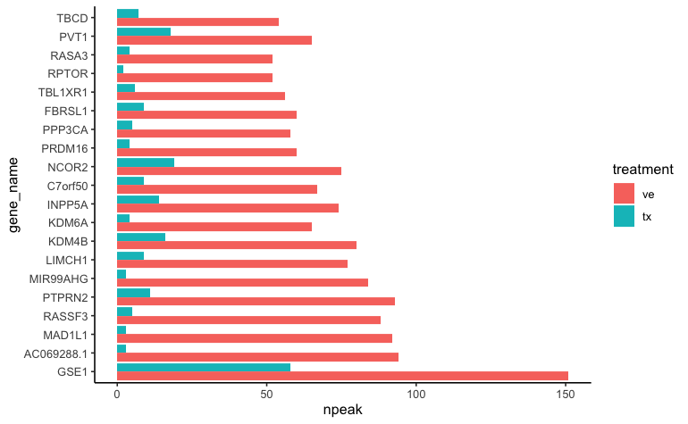

```r
gene_df %>% head(20) %>%
    dplyr::select(-diff, -gene_id) %>%
    mutate(gene_name = factor(gene_name, levels = gene_name)) %>%
    melt(id.vars = "gene_name", variable.name = "treatment", value.name = "npeak") %>%
    ggplot() +
    geom_col(aes(gene_name, npeak, fill = treatment), position = "dodge") +
    coord_flip()
```

## GO enrichment

```r
library(clusterProfiler)
gene_down = bitr(gene_df$gene_id[gene_df$diff > 0], fromType = "ENSEMBL", toType = "ENTREZID", OrgDb = org.Hs.eg.db, drop = TRUE)
```

```
24.97% of input gene IDs are fail to map...
```

```r
gene_bg = bitr(gene_df$gene_id, fromType = "ENSEMBL", toType = "ENTREZID", OrgDb = org.Hs.eg.db, drop = TRUE)
```

```
25.46% of input gene IDs are fail to map...
```

```r
ego = enrichGO(
    gene = gene_down$ENTREZID,
    OrgDb = org.Hs.eg.db,
    ont = "ALL",
    pvalueCutoff = 0.01,
    qvalueCutoff = 0.05,
    readable = TRUE
)
# write.table(ego@result, file = "go_enrichment.txt", sep = "\t", quote = FALSE, row.names = FALSE)
ego@result %>% dplyr::select(-ID, -geneID) %>%
    DT::datatable() %>%
    DT::formatSignif(columns = 5:7, digits = 3)
```

|  | ONTOLOGY | Description | GeneRatio | BgRatio | pvalue | p.adjust | qvalue | Count |
| --- | --- | --- | --- | --- | --- | --- | --- | --- |
| GO:0000226 | BP | microtubule cytoskeleton organization | 435/13010 | 460/17913 | 1.10122122184316e-34 | 6.87272164552318e-31 | 4.26346489888332e-31 | 435 |
| GO:0034660 | BP | ncRNA metabolic process | 438/13010 | 470/17913 | 1.93866087432929e-30 | 6.04959125834456e-27 | 3.75283931357007e-27 | 438 |
| GO:0048667 | BP | cell morphogenesis involved in neuron differentiation | 457/13010 | 500/17913 | 2.34467532774011e-26 | 3.23329342023693e-23 | 2.00576041282713e-23 | 457 |
| GO:0016569 | BP | covalent chromatin modification | 401/13010 | 433/17913 | 2.35308845142778e-26 | 3.23329342023693e-23 | 2.00576041282713e-23 | 401 |
| GO:0016570 | BP | histone modification | 390/13010 | 420/17913 | 2.59036486159023e-26 | 3.23329342023693e-23 | 2.00576041282713e-23 | 390 |
| GO:0072594 | BP | establishment of protein localization to organelle | 413/13010 | 452/17913 | 7.51969952665253e-24 | 7.82174079097307e-21 | 4.85218506298737e-21 | 413 |
| GO:0010498 | BP | proteasomal protein catabolic process | 354/13010 | 382/17913 | 1.53792223871291e-23 | 1.37116752740104e-20 | 8.50598194584375e-21 | 354 |
| GO:0198738 | BP | cell-cell signaling by wnt | 452/13010 | 500/17913 | 2.01186009121933e-23 | 1.56950235366248e-20 | 9.73634396776934e-21 | 452 |
| GO:0016055 | BP | Wnt signaling pathway | 450/13010 | 498/17913 | 3.16559429829831e-23 | 2.19516377951997e-20 | 1.36176091568903e-20 | 450 |
| GO:0018205 | BP | peptidyl-lysine modification | 348/13010 | 376/17913 | 6.88657540755214e-23 | 4.29791171185329e-20 | 2.6661920367344e-20 | 348 |

[output cut: 1678 more lines]

Download the go enrichment table:

[Download](https://raw.githubusercontent.com/zhuchcn/sr8278/master/go_enrichment.txt)

## Export data

```r
library(jsonlite)
names(gene_df)[3:4] = c("npeaks_vs", "npeaks_tx")
entrez = bitr(gene_df$gene_id, fromType = "ENSEMBL", toType = c("ENSEMBL", "ENTREZID"), OrgDb = org.Hs.eg.db)
```

```
25.46% of input gene IDs are fail to map...
```

```r
ggo = enrichGO(entrez$ENTREZID, OrgDb = org.Hs.eg.db, ont = "ALL", readable = TRUE)
# write.table(gene_df, "gene_table.txt", sep = "\t", row.names = FALSE, quote = FALSE)
# write.table(entrez, "gene_entrezid.txt", sep = "\t", row.names = FALSE, quote = FALSE)
# write_json(ggo@geneSets, "go_geneset.json")
```

Download the result table:

[Download](https://raw.githubusercontent.com/zhuchcn/sr8278/master/gene_table_goids.txt)

## peak regions

```r
peakAnno_tx = annotatePeak(tx_granges, TxDb = TxDb.Hsapiens.UCSC.hg38.knownGene, annoDb = "org.Hs.eg.db", level = "gene")
```

```
>> preparing features information...         2020-01-16 23:26:58
>> identifying nearest features...       2020-01-16 23:26:59
>> calculating distance from peak to TSS...  2020-01-16 23:27:00
>> assigning genomic annotation...       2020-01-16 23:27:00
>> adding gene annotation...             2020-01-16 23:27:27
>> assigning chromosome lengths          2020-01-16 23:27:27
>> done...                   2020-01-16 23:27:27
```

```r
peakAnno_ve = annotatePeak(ve_granges, TxDb = TxDb.Hsapiens.UCSC.hg38.knownGene, annoDb = "org.Hs.eg.db", level = "gene")
```

```
>> preparing features information...         2020-01-16 23:27:27
>> identifying nearest features...       2020-01-16 23:27:27
>> calculating distance from peak to TSS...  2020-01-16 23:27:28
>> assigning genomic annotation...       2020-01-16 23:27:28
>> adding gene annotation...             2020-01-16 23:27:32
>> assigning chromosome lengths          2020-01-16 23:27:32
>> done...                   2020-01-16 23:27:32
```

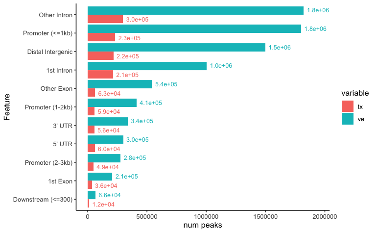

```r
data.frame(
    Feature = peakAnno_tx@annoStat$Feature,
    tx = peakAnno_tx@annoStat$Frequency * peakAnno_tx@peakNum,
    ve = peakAnno_ve@annoStat$Frequency * peakAnno_ve@peakNum
) %>%
    arrange(ve) %>%
    mutate(Feature = factor(Feature, levels = Feature)) %>%
    melt(id.vars = "Feature") %>%
    ggplot() +
    geom_col(aes(x = Feature, y = value, fill = variable), position = "dodge") +
    geom_text(aes(x = Feature, y = value + max(value)/15,
                  label = formatC(value, format = "e", digit = 1), color = variable),
              position = position_dodge(width = 1), size = 3) +
    coord_flip() +
    labs(y = "num peaks")
```

## RNAseq data

### 8278 48h

```r
rep1 = read.table("data/rsem_genes_results-8278_48h.txt", sep = "\t", header = TRUE)
rep2 = read.table("data/rsem_genes_results-8278_CON.txt", sep = "\t", header = TRUE)
fpkm_48h = data.frame(
    gene_id = rep1$gene_id,
    `48h` = rep1$FPKM,
    con = rep2$FPKM
) %>% filter(grepl("^ENSG", gene_id)) %>%
    filter(X48h != 0 & con != 0) %>%
    mutate(gene_id = gsub("\\.[0-9]+$", "", gene_id))
# down_reg_genes = fpmk$gene_id[fpmk$X48h < fpmk$con]
gene_48h = left_join(gene_df, fpkm_48h, by = "gene_id") %>%
    filter(X48h < con & diff > 0) %>%
    mutate(fpkm_diff = con - X48h)
colnames(gene_48h) = c("gene_id", "gene_name", "npeaks_ve", "npeaks_tx", "npeaks_diff", "fpkm_48h", "fpkm_con", "fpkm_diff")
write.table(gene_48h, file = "gene_table-npeaks_fpmk-27ac_me1_vs_8278_48h.txt", sep = "\t", quote = FALSE, row.names = FALSE)
```

Download the gene table with histone modification npeaks and RNAseq fpmk:

[Download](https://raw.githubusercontent.com/zhuchcn/sr8278/master/gene_table-npeaks_fpmk-27ac_me1_vs_8278_48h.txt)

```r
gene_down = bitr(gene_48h$gene_id, fromType = "ENSEMBL", toType = "ENTREZID", OrgDb = org.Hs.eg.db, drop = TRUE)
```

```
11.35% of input gene IDs are fail to map...
```

```r
gene_bg = bitr(gene_48h$gene_id, fromType = "ENSEMBL", toType = "ENTREZID", OrgDb = org.Hs.eg.db, drop = TRUE)
```

```
11.35% of input gene IDs are fail to map...
```

```r
ego_48h = enrichGO(
    gene = gene_down$ENTREZID,
    OrgDb = org.Hs.eg.db,
    ont = "ALL",
    pvalueCutoff = 0.01,
    qvalueCutoff = 0.05,
    readable = TRUE
)
write.table(ego_48h@result, file = "go_enrichment-27ac_me1_vs_8278_48h.txt", sep = "\t", quote = FALSE, row.names = FALSE)
ego_48h@result %>% dplyr::select(-ID, -geneID) %>%
    DT::datatable() %>%
    DT::formatSignif(columns = 5:7, digits = 3)
```

|  | ONTOLOGY | Description | GeneRatio | BgRatio | pvalue | p.adjust | qvalue | Count |
| --- | --- | --- | --- | --- | --- | --- | --- | --- |
| GO:0034660 | BP | ncRNA metabolic process | 275/6417 | 470/17913 | 3.29388704700673e-24 | 2.04715079971468e-20 | 1.7821662549068e-20 | 275 |
| GO:0060271 | BP | cilium assembly | 206/6417 | 335/17913 | 5.17975798611944e-22 | 1.46853120529399e-18 | 1.27844356102996e-18 | 206 |
| GO:0044782 | BP | cilium organization | 211/6417 | 346/17913 | 7.08864620415443e-22 | 1.46853120529399e-18 | 1.27844356102996e-18 | 211 |
| GO:0034470 | BP | ncRNA processing | 183/6417 | 293/17913 | 9.21533604592186e-21 | 1.43183283813511e-17 | 1.24649545463259e-17 | 183 |
| GO:0006260 | BP | DNA replication | 165/6417 | 260/17913 | 7.28407361975807e-20 | 9.05410350935928e-17 | 7.88213440116978e-17 | 165 |
| GO:0006403 | BP | RNA localization | 138/6417 | 208/17913 | 2.41240803598994e-19 | 2.36987498583119e-16 | 2.06311681029298e-16 | 138 |
| GO:0031503 | BP | protein-containing complex localization | 153/6417 | 238/17913 | 2.66920754639072e-19 | 2.36987498583119e-16 | 2.06311681029298e-16 | 153 |
| GO:0015931 | BP | nucleobase-containing compound transport | 140/6417 | 221/17913 | 5.75727102161362e-17 | 4.47267992491608e-14 | 3.89373329619658e-14 | 140 |
| GO:0051052 | BP | regulation of DNA metabolic process | 225/6417 | 403/17913 | 1.05056638102082e-16 | 7.25474450893825e-14 | 6.31568561221876e-14 | 225 |
| GO:0006261 | BP | DNA-dependent DNA replication | 91/6417 | 130/17913 | 1.98821185772413e-15 | 1.23567366957555e-12 | 1.07572725775811e-12 | 91 |

[output cut: 540 more lines]

Download the go enrichment result of genes that may decrease in me1 and 27ac histone modification and may decrease in gene expression:

[Download](https://raw.githubusercontent.com/zhuchcn/sr8278/master/go_enrichment-27ac_me1_vs_8278_48h.txt)

### 8278 24h

```r
rep1 = read.table("data/rsem_genes_results-8278_24h.txt", sep = "\t", header = TRUE)
rep2 = read.table("data/rsem_genes_results-8278_CON.txt", sep = "\t", header = TRUE)
fpkm_24h = data.frame(
    gene_id = rep1$gene_id,
    `24h` = rep1$FPKM,
    con = rep2$FPKM
) %>% filter(grepl("^ENSG", gene_id)) %>%
    filter(X24h != 0 & con != 0) %>%
    mutate(gene_id = gsub("\\.[0-9]+$", "", gene_id))
gene_24h = left_join(gene_df, fpkm_24h, by = "gene_id") %>%
    filter(X24h < con & diff > 0) %>%
    mutate(fpkm_diff = con - X24h)
colnames(gene_24h) = c("gene_id", "gene_name", "npeaks_ve", "npeaks_tx", "npeaks_diff", "fpkm_24h", "fpkm_con", "fpkm_diff")
write.table(gene_24h, file = "gene_table-npeaks_fpmk-27ac_me1_vs_8278_24h.txt", sep = "\t", quote = FALSE, row.names = FALSE)
```

Download the gene table with histone modification npeaks and RNAseq fpmk:

[Download](https://raw.githubusercontent.com/zhuchcn/sr8278/master/gene_table-npeaks_fpmk-27ac_me1_vs_8278_24h.txt)

```r
gene_down = bitr(gene_24h$gene_id, fromType = "ENSEMBL", toType = "ENTREZID", OrgDb = org.Hs.eg.db, drop = TRUE)
```

```
11.53% of input gene IDs are fail to map...
```

```r
gene_bg = bitr(gene_24h$gene_id, fromType = "ENSEMBL", toType = "ENTREZID", OrgDb = org.Hs.eg.db, drop = TRUE)
```

```
11.53% of input gene IDs are fail to map...
```

```r
ego_24h = enrichGO(
    gene = gene_down$ENTREZID,
    OrgDb = org.Hs.eg.db,
    ont = "ALL",
    pvalueCutoff = 0.01,
    qvalueCutoff = 0.05,
    readable = TRUE
)
write.table(ego_24h@result, file = "go_enrichment-27ac_me1_vs_8278_24h.txt", sep = "\t", quote = FALSE, row.names = FALSE)
ego_24h@result %>% dplyr::select(-ID, -geneID) %>%
    DT::datatable() %>%
    DT::formatSignif(columns = 5:7, digits = 3)
```

|  | ONTOLOGY | Description | GeneRatio | BgRatio | pvalue | p.adjust | qvalue | Count |
| --- | --- | --- | --- | --- | --- | --- | --- | --- |
| GO:0006260 | BP | DNA replication | 174/6193 | 260/17913 | 1.07494882837132e-26 | 6.6646827359022e-23 | 5.86243145241245e-23 | 174 |
| GO:0034660 | BP | ncRNA metabolic process | 268/6193 | 470/17913 | 6.34434362213735e-24 | 1.96674652286258e-20 | 1.73000233191019e-20 | 268 |
| GO:0006261 | BP | DNA-dependent DNA replication | 97/6193 | 130/17913 | 1.0117664481285e-20 | 2.0909839927989e-17 | 1.83928490096623e-17 | 97 |
| GO:0034470 | BP | ncRNA processing | 176/6193 | 293/17913 | 2.64849711115634e-19 | 4.10517052229233e-16 | 3.61101671918448e-16 | 176 |
| GO:0006310 | BP | DNA recombination | 150/6193 | 244/17913 | 6.07973942998391e-18 | 7.20919400521105e-15 | 6.34139798658717e-15 | 150 |
| GO:0006302 | BP | double-strand break repair | 134/6193 | 211/17913 | 6.97663935988166e-18 | 7.20919400521105e-15 | 6.34139798658717e-15 | 134 |
| GO:0006403 | BP | RNA localization | 132/6193 | 208/17913 | 1.34244424626502e-17 | 1.18902204669188e-14 | 1.04589528419535e-14 | 132 |
| GO:0031503 | BP | protein-containing complex localization | 145/6193 | 238/17913 | 6.70850587497519e-17 | 5.19909205310577e-14 | 4.5732590708219e-14 | 145 |
| GO:0015931 | BP | nucleobase-containing compound transport | 136/6193 | 221/17913 | 1.88514454557064e-16 | 1.29865513139311e-13 | 1.14233144919316e-13 | 136 |
| GO:0000724 | BP | double-strand break repair via homologous recombination | 79/6193 | 108/17913 | 2.75020707308722e-16 | 1.70512838531408e-13 | 1.49987608901736e-13 | 79 |

[output cut: 500 more lines]

Download the go enrichment result of genes that may decrease in me1 and 27ac histone modification and may decrease in gene expression:

[Download](https://raw.githubusercontent.com/zhuchcn/sr8278/master/go_enrichment-27ac_me1_vs_8278_24h.txt)

### sh rev (don’t even know what that means)

```r
sh4 = read.table("data/rsem_genes_results-sh4_rev.txt", sep = "\t", header = TRUE)
sh5 = read.table("data/rsem_genes_results-sh5_rev.txt", sep = "\t", header = TRUE)
sicon = read.table("data/rsem_genes_results-sicon_rev.txt", sep = "\t", header = TRUE)
fpkm_sh = data.frame(
    gene_id = sh4$gene_id,
    sh4 = sh4$FPKM,
    sh5 = sh5$FPKM,
    sicon = sicon$FPKM
) %>% filter(grepl("^ENSG", gene_id)) %>%
    filter(sh4 != 0 & sh5 != 0 & sicon != 0) %>%
    mutate(gene_id = gsub("\\.[0-9]+$", "", gene_id))
gene_sh = left_join(gene_df, fpkm_sh, by = "gene_id") %>%
    filter(sh4 < sicon & sh5 < sicon & diff > 0) %>%
    mutate(fpkm_diff_sh4 = sicon - sh4, fpkm_diff_sh5 = sicon - sh5)
colnames(gene_sh) = c("gene_id", "gene_name", "npeaks_ve", "npeaks_tx", "npeaks_diff", "fpkm_sh4", "fpkm_sh5", "fpkm_sicon", "fpkm_diff_sh4", "fpkm_diff_sh5")
write.table(gene_sh, file = "gene_table-npeaks_fpmk-27ac_me1_vs_sh_rev.txt", sep = "\t", quote = FALSE, row.names = FALSE)
```

Download the gene table with histone modification npeaks and RNAseq fpmk:

[Download](https://raw.githubusercontent.com/zhuchcn/sr8278/master/gene_table-npeaks_fpmk-27ac_me1_vs_sh_rev.txt)

```r
gene_down = bitr(gene_sh$gene_id, fromType = "ENSEMBL", toType = "ENTREZID", OrgDb = org.Hs.eg.db, drop = TRUE)
```

```
14.07% of input gene IDs are fail to map...
```

```r
gene_bg = bitr(gene_sh$gene_id, fromType = "ENSEMBL", toType = "ENTREZID", OrgDb = org.Hs.eg.db, drop = TRUE)
```

```
14.07% of input gene IDs are fail to map...
```

```r
ego_sh = enrichGO(
    gene = gene_down$ENTREZID,
    OrgDb = org.Hs.eg.db,
    ont = "ALL",
    pvalueCutoff = 0.01,
    qvalueCutoff = 0.05,
    readable = TRUE
)
write.table(ego_sh@result, file = "go_enrichment-27ac_me1_vs_sh_rev.txt", sep = "\t", quote = FALSE, row.names = FALSE)
ego_sh@result %>% dplyr::select(-ID, -geneID) %>%
    DT::datatable() %>%
    DT::formatSignif(columns = 5:7, digits = 3)
```

|  | ONTOLOGY | Description | GeneRatio | BgRatio | pvalue | p.adjust | qvalue | Count |
| --- | --- | --- | --- | --- | --- | --- | --- | --- |
| GO:0000184 | BP | nuclear-transcribed mRNA catabolic process, nonsense-mediated decay | 46/2263 | 118/17913 | 3.90961038479918e-13 | 2.287513036146e-09 | 2.16139723589108e-09 | 46 |
| GO:0019083 | BP | viral transcription | 58/2263 | 177/17913 | 2.20577035036248e-12 | 6.45298115998545e-09 | 6.09721362110725e-09 | 58 |
| GO:0019080 | BP | viral gene expression | 60/2263 | 191/17913 | 6.98073350535507e-12 | 1.36147572466108e-08 | 1.28641446912719e-08 | 60 |
| GO:0006614 | BP | SRP-dependent cotranslational protein targeting to membrane | 39/2263 | 103/17913 | 6.72490994501661e-11 | 8.86338038998478e-08 | 8.37472205528521e-08 | 39 |
| GO:0045047 | BP | protein targeting to ER | 40/2263 | 108/17913 | 8.51862778451293e-11 | 8.86338038998478e-08 | 8.37472205528521e-08 | 40 |
| GO:0000956 | BP | nuclear-transcribed mRNA catabolic process | 59/2263 | 197/17913 | 9.08909286274289e-11 | 8.86338038998478e-08 | 8.37472205528521e-08 | 59 |
| GO:0090150 | BP | establishment of protein localization to membrane | 76/2263 | 287/17913 | 1.42140229802266e-10 | 1.1880892636758e-07 | 1.1225871983782e-07 | 76 |
| GO:0006613 | BP | cotranslational protein targeting to membrane | 39/2263 | 106/17913 | 1.84001469874954e-10 | 1.34574075029795e-07 | 1.27154699971482e-07 | 39 |
| GO:0072599 | BP | establishment of protein localization to endoplasmic reticulum | 40/2263 | 112/17913 | 3.07124095042013e-10 | 1.99664786676758e-07 | 1.8865681253341e-07 | 40 |
| GO:0006413 | BP | translational initiation | 54/2263 | 183/17913 | 1.02541608333274e-09 | 5.99970950357986e-07 | 5.66893186280374e-07 | 54 |

[output cut: 24 more lines]

Download the go enrichment result of genes that may decrease in me1 and 27ac histone modification and may decrease in gene expression:

[Download](https://raw.githubusercontent.com/zhuchcn/sr8278/master/go_enrichment-27ac_me1_vs_sh_rev.txt)